# Module 6 group work

```r
library(ggplot2) #load ggplot
library(ggthemes) #load themes package for ggplot
theme_set(theme_tufte()) # a theme I like.

#set some options that I like
theme_update(plot.title = element_text(hjust = 0.5),
             axis.line.x = element_line(color="black", size = 1),
             axis.line.y = element_line(color="black", size = 1),
             text=element_text(size=20),
             axis.text=element_text(size=15)) #center all titles and and axis lines
```

This example uses data from the Maryland Biological Stream Survey, downloaded from: http://udel.edu/~mcdonald/statmultreg.html. We are interested in predicting the abundance of longnose dace using chemical and biological characteristics of a stream.

The dependent variable is the number of longnose dace, **longnosedace**, per 75-meter section of stream. The independent variables are the **acreage** drained by the stream; the dissolved oxygen, **do2**, in mg/liter; the maximum depth, **maxdepth**, in cm of the 75-meter segment of stream; nitrate concentration, **no3**, in mg/liter; sulfate concentration, **so4**, in mg/liter; water temperature, **temp**, on the sampling date in degrees C, and the stream conductivity, **conduct**, in uS/cm.

1. Read in `longnosedace.csv` and create a linear model of longnosedace with all the above covariates in the model.
2. load the `car` library and calculate the variance inflation factors using the function `vif`. Based on this diagnostic, which predictor would you remove from the model to increase estimate interpretability?

```r
#code here
library(car)
dace.dat <- read.csv(file="../Data/longnosedace.csv")
full.mod <- lm(longnosedace ~ acreage + do2 + maxdepth + no3 + so4 + temp + conduct, data=dace.dat)
vif(full.mod)
```

```
 acreage      do2 maxdepth      no3      so4     temp  conduct
1.104984 3.202636 1.161897 5.009860 1.023701 1.141963 8.384964
```

```r
summary(full.mod)
```

```
Call:
lm(formula = longnosedace ~ acreage + do2 + maxdepth + no3 +
    so4 + temp + conduct, data = dace.dat)

Residuals:
    Min      1Q  Median      3Q     Max
-56.434 -23.811  -3.489  12.136 170.002

Coefficients:
              Estimate Std. Error t value Pr(>|t|)
(Intercept) -1.435e+02  6.836e+01  -2.100  0.03996 *
acreage      2.042e-03  6.802e-04   3.002  0.00391 **
do2          1.288e+01  8.714e+00   1.478  0.14468
maxdepth     4.004e-01  1.845e-01   2.170  0.03396 *
no3          1.309e+01  6.163e+00   2.123  0.03785 *
so4         -5.231e-02  7.749e-01  -0.068  0.94640
temp         2.927e+00  1.704e+00   1.718  0.09104 .
conduct     -5.589e-01  5.653e-01  -0.989  0.32676
---
Signif. codes:  0 ‘***’ 0.001 ‘**’ 0.01 ‘*’ 0.05 ‘.’ 0.1 ‘ ’ 1

Residual standard error: 41.06 on 60 degrees of freedom
Multiple R-squared:  0.325, Adjusted R-squared:  0.2462
F-statistic: 4.127 on 7 and 60 DF,  p-value: 0.0009229
```

### Based on the vif I would remove the conduct variable to improve interpretability of the model parameters.

Now create another model of the longose dace, onw with just the predictors `acreage` and `maxdepth`.

1. Report the adjusted $R^2$ values for this model and the full model from above. Based on this criterion, which is the better model?
2. Now run an F-test on the two models with the `anova` function. What does the p-value tell you?

```r
# code here
red.mod <- lm(longnosedace ~ acreage + maxdepth, data=dace.dat)
summary(red.mod)
```

```
Call:
lm(formula = longnosedace ~ acreage + maxdepth, data = dace.dat)

Residuals:
    Min      1Q  Median      3Q     Max
-69.753 -23.302  -9.897  12.784 192.411

Coefficients:
              Estimate Std. Error t value Pr(>|t|)
(Intercept) -1.4503313 14.3765306  -0.101   0.9200
acreage      0.0017497  0.0007137   2.451   0.0169 *
maxdepth     0.3724306  0.1887901   1.973   0.0528 .
---
Signif. codes:  0 ‘***’ 0.001 ‘**’ 0.01 ‘*’ 0.05 ‘.’ 0.1 ‘ ’ 1

Residual standard error: 43.75 on 65 degrees of freedom
Multiple R-squared:  0.1698,    Adjusted R-squared:  0.1442
F-statistic: 6.646 on 2 and 65 DF,  p-value: 0.002365
```

```r
anova(full.mod, red.mod)
```

```
Analysis of Variance Table

Model 1: longnosedace ~ acreage + do2 + maxdepth + no3 + so4 + temp +
    conduct
Model 2: longnosedace ~ acreage + maxdepth
  Res.Df    RSS Df Sum of Sq      F  Pr(>F)
1     60 101139
2     65 124393 -5    -23255 2.7591 0.02615 *
---
Signif. codes:  0 ‘***’ 0.001 ‘**’ 0.01 ‘*’ 0.05 ‘.’ 0.1 ‘ ’ 1
```

### The p-value in the F-test indicates that the full model explains a significantly different amount of variation than the reduced model. This is consistent with conclusions from the adjusted $R^2$.

In 1981 bluegills (`bluegills.csv`) were randomly sampled from Lake Mary in Minnesota. The researchers (Cook and Weisberg, 1999) measured and recorded the length (in mm) of the fish and the age (in years) of the fish. The researchers wanted to know how to predict fish length just from knowledge of the fish age.

1. Fit two models to the dataset. In the first use just age as the predictor, in the second model fit age + age^2. In order to incorporate this quadratic term, you need to use the ‘as is’ command `I(age^2)` as your predictor variable. Otherwise R doesn’t understand you are using a quadratic term.
2. Plot the model predictions using the command `plot_model` in the `sjPlot` package. Which model looks like a better fit?
3. Calculate the adjusted $R^2$ and perform an F-test to determine which model is a better fit to the data.
4. Report the confidence intervals from the model with the quadratic term. Do the confidence intervals overlap 0?

```r
library(sjPlot)
library(gridExtra)
#code here
blue.dat <- read.csv(file="../Data/bluegills.csv")

mod1 <- lm(length ~ age, data=blue.dat)
summary(mod1)
```

```
Call:
lm(formula = length ~ age, data = blue.dat)

Residuals:
    Min      1Q  Median      3Q     Max
-26.523  -7.586   0.258  10.102  20.414

Coefficients:
            Estimate Std. Error t value Pr(>|t|)
(Intercept)   62.649      5.755   10.89   <2e-16 ***
age           22.312      1.537   14.51   <2e-16 ***
---
Signif. codes:  0 ‘***’ 0.001 ‘**’ 0.01 ‘*’ 0.05 ‘.’ 0.1 ‘ ’ 1

Residual standard error: 12.51 on 76 degrees of freedom
Multiple R-squared:  0.7349,    Adjusted R-squared:  0.7314
F-statistic: 210.7 on 1 and 76 DF,  p-value: < 2.2e-16
```

```r
mod2 <- lm(length ~ age + I(age^2), data=blue.dat)
summary(mod2)
```

```
Call:
lm(formula = length ~ age + I(age^2), data = blue.dat)

Residuals:
    Min      1Q  Median      3Q     Max
-19.846  -8.321  -1.137   6.698  22.098

Coefficients:
            Estimate Std. Error t value Pr(>|t|)
(Intercept)   13.622     11.016   1.237     0.22
age           54.049      6.489   8.330 2.81e-12 ***
I(age^2)      -4.719      0.944  -4.999 3.67e-06 ***
---
Signif. codes:  0 ‘***’ 0.001 ‘**’ 0.01 ‘*’ 0.05 ‘.’ 0.1 ‘ ’ 1

Residual standard error: 10.91 on 75 degrees of freedom
Multiple R-squared:  0.8011,    Adjusted R-squared:  0.7958
F-statistic: 151.1 on 2 and 75 DF,  p-value: < 2.2e-16
```

```r
anova(mod1, mod2)
```

```
Analysis of Variance Table

Model 1: length ~ age
Model 2: length ~ age + I(age^2)
  Res.Df     RSS Df Sum of Sq      F    Pr(>F)
1     76 11892.8
2     75  8920.7  1    2972.1 24.988 3.675e-06 ***
---
Signif. codes:  0 ‘***’ 0.001 ‘**’ 0.01 ‘*’ 0.05 ‘.’ 0.1 ‘ ’ 1
```

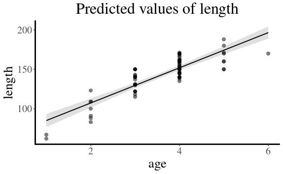

```r
plot_model(mod1, type="pred", show.data=TRUE)
```

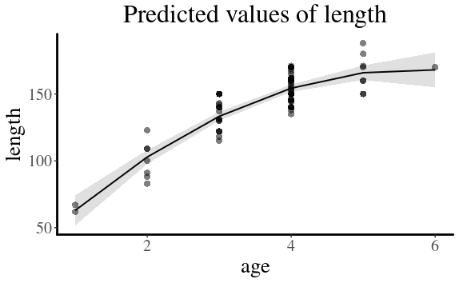

```r
plot_model(mod2, type="pred", show.data=TRUE)
```

```r
confint(mod2)
```

```
                2.5 %    97.5 %
(Intercept) -8.323378 35.568130
age         41.122877 66.975747
I(age^2)    -6.599128 -2.838202
```

### The linear model does well for intermediate ages but not at low or high ages. The quadratic term does a better job overall of fitting the data. The adjusted $R^2$ is higher for the model with the quadratic term and the p-value for the F-test is significant, indicating that the quadratic model significantly differs from the linear model. The confidence intervals on the quadratic model show that the likely coefficient values for the quadratic term does not overlap 0, indicating it differs from 0.

Perform model selection using AIC on the bluegill models using the `MuMIn` package. Does AICc agree with your conclusions from the F-test and with the adjusted $R^2$?

```r
#code here
library(MuMIn)
model.sel(list(mod1, mod2))
```

```
Model selection table
  (Intrc)   age  age^2 df   logLik  AICc delta weight
2   13.62 54.05 -4.719  4 -295.515 599.6  0.00      1
1   62.65 22.31         3 -306.730 619.8 20.21      0
Models ranked by AICc(x)
```

### AICc selects the quadratic model. This is consistent with the F-test and adjusted $R^2$.

For the mammal-sleep dataset (`MammalSleep.csv`), the best entry in our prediction completion discussed briefly in the lecture came from a student who built three models. Model 1 included `LifeSpan` and `Exposure`. Model 2 included `Danger` and `Predation`. Model 3 included just `Exposure`. Fit these three models to the data, then use LOOCV (adapting the code from lecture) to determine which model has the best predictive properties.

Follow this by performing model selection using AICc. Is the model ranking the same as cross-validation?

```r
library(caret)
library(MuMIn)
#code here
sleep.dat <- read.csv(file="../Data/MammalSleep.csv")
sleep.dat <- sleep.dat[complete.cases(sleep.dat), ] #remove NA's

sleep.control <- trainControl(method = "LOOCV") #tell the function we want to do leave one out cross validation
mod1.xv <- train(TotalSleep ~ LifeSpan + Exposure, data=sleep.dat, method = "lm", trControl=sleep.control)
mod2.xv <- train(TotalSleep ~ Danger + Predation, data=sleep.dat, method = "lm", na.action=na.omit, trControl=sleep.control)
mod3.xv <- train(TotalSleep ~ Exposure, data=sleep.dat, method = "lm", na.action=na.omit, trControl=sleep.control)

print(mod1.xv$results)
```

|  | intercept | RMSE | Rsquared | MAE |
| --- | --- | --- | --- | --- |
| 1 | TRUE | 3.863014 | 0.3229362 | 3.029086 |

```r
print(mod2.xv$results)
```

|  | intercept | RMSE | Rsquared | MAE |
| --- | --- | --- | --- | --- |
| 1 | TRUE | 3.359188 | 0.4805744 | 2.76409 |

```r
print(mod3.xv$results)
```

|  | intercept | RMSE | Rsquared | MAE |
| --- | --- | --- | --- | --- |
| 1 | TRUE | 3.721183 | 0.3604184 | 2.906917 |

```r
mod1 <- lm(TotalSleep ~ LifeSpan + Exposure, data=sleep.dat)
mod2 <- lm(TotalSleep ~ Danger + Predation, data=sleep.dat)
mod3 <- lm(TotalSleep ~ Exposure, data=sleep.dat)

model.sel(list(mod1, mod2, mod3))
```

```
Model selection table
  (Intrc)  Expsr    LfSpn  Dangr Prdtn df  logLik  AICc delta weight
2   15.01                 -5.573 3.566  4 -89.205 187.7  0.00  0.945
3   15.58 -2.066                        3 -93.811 194.4  6.65  0.034
1   15.99 -1.924 -0.04266               4 -93.009 195.4  7.61  0.021
Models ranked by AICc(x)
```

### Based on the cross-validation we would select model 2, with Danger and Predation as predictors, as the best predictive model followed by the model with Exposure and then by Expression and Lifespan. The AICc rankings are identical to the LOOCV ranking.